# PS5

# 4 GDP per capita (50pt)

Let’s look at GDP per capita (*GDP_PC*)

1. (8pt) Make a scatterplot of GDP per capita versus life expectancy by country, using data for 1960. Make the point size dependent on the country size, and color those according to the continent. Feel free to adjust the plot in other ways to make it better.  
   Comment what do you see there.

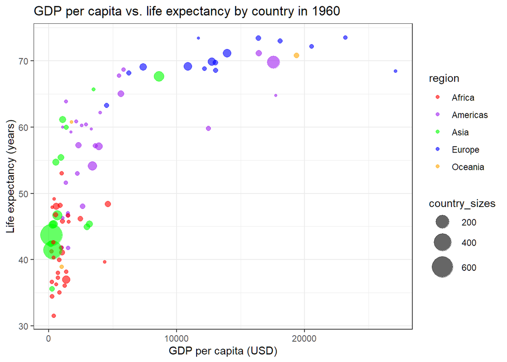

```r
data_1960 <- gapdata %>%
  filter(time == 1960 & !is.na(GDP_PC) & !is.na(lifeExpectancy) & !is.na(region) & !is.na(name))

# Create a named vector of colors for each continent
continent_colors <- c("Africa" = "red", "Asia" = "green", "Europe" = "blue", "Americas" = "purple", "Oceania" = "orange")

# Create a named vector of sizes for each country
country_sizes <- setNames(data_1960$totalPopulation / 1000000, data_1960$name)

# Create the plot
ggplot(data_1960, aes(x = GDP_PC, y = lifeExpectancy, color = region)) +
  geom_point(aes(size = country_sizes), alpha = 0.6) +
  scale_color_manual(values = continent_colors) +
  scale_size_continuous(range = c(1, 10)) +
  labs(title = "GDP per capita vs. life expectancy by country in 1960", x = "GDP per capita (USD)", y = "Life expectancy (years)") +
  theme_bw()
```

```r
# the poorer countries (by GDP) have a lower life expectancy
```

```
\
The poorer countries (by GDP) have a lower life expectancy. \
```

2. (4pt) Make a similar plot, but this time use 2019 data only.

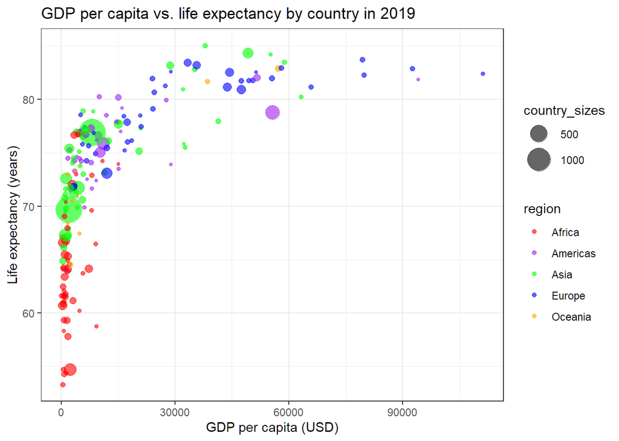

```r
# Select the relevant columns and remove rows with missing data
data_1960 <- gapdata %>%
  filter(time == 2019 & !is.na(GDP_PC) & !is.na(lifeExpectancy) & !is.na(region) & !is.na(name))

# Create a named vector of colors for each continent
continent_colors <- c("Africa" = "red", "Asia" = "green", "Europe" = "blue", "Americas" = "purple", "Oceania" = "orange")

# Create a named vector of sizes for each country
country_sizes <- setNames(data_1960$totalPopulation / 1000000, data_1960$name)

# Create the plot
ggplot(data_1960, aes(x = GDP_PC, y = lifeExpectancy, color = region)) +
  geom_point(aes(size = country_sizes), alpha = 0.6) +
  scale_color_manual(values = continent_colors) +
  scale_size_continuous(range = c(1, 10)) +
  labs(title = "GDP per capita vs. life expectancy by country in 2019", x = "GDP per capita (USD)", y = "Life expectancy (years)") +
  theme_bw()
```

3. (6pt) Compare these two plots and comment what do you see. How has world developed through the last 60 years?

```r
# Compute the average life expectancy for each continent in 1960 and 2019
life_expectancy_avg <- gapdata %>%
  filter(!is.na(lifeExpectancy) & !is.na(time) & time %in% c(1960, 2019) & !is.na(region)) %>%
  group_by(region, time) %>%
  summarize(avg_life_expectancy = mean(lifeExpectancy),.groups="drop")

# Print the results
knitr::kable(life_expectancy_avg)
```

| region | time | avg_life_expectancy |
| --- | --- | --- |
| Africa | 1960 | 41.46600 |
| Africa | 2019 | 64.11014 |
| Americas | 1960 | 58.64651 |
| Americas | 2019 | 75.83206 |
| Asia | 1960 | 51.64931 |
| Asia | 2019 | 74.61739 |
| Europe | 1960 | 68.28254 |
| Europe | 2019 | 79.35714 |
| Oceania | 1960 | 56.39613 |
| Oceania | 2019 | 73.52827 |

```r
#Yes
```

```
Yes these results align with the figures.
```

5. (8pt) Compute the average LE growth from 1960-2019 across the continents. Show the results in the order of growth. Explain what do you see.  
   Hint: these data (data in long form) is not the simplest to compute growth. But you may want to check out the lag() function. And do not forget to group data by continent when using lag(), otherwise your results will be messed up! See [**https://faculty.washington.edu/otoomet/info201-book/dplyr.html#dplyr-helpers-compute**](https://faculty.washington.edu/otoomet/info201-book/dplyr.html#dplyr-helpers-compute).

```r
# Compute the average life expectancy growth from 1960 to 2019 by continent
life_expectancy_growth <- gapdata %>%
  filter(!is.na(lifeExpectancy) & !is.na(time) & time %in% c(1960, 2019) & !is.na(region)) %>%
  group_by(region) %>%
  mutate(avg_growth = (lifeExpectancy - lag(lifeExpectancy))/lag(lifeExpectancy)) %>%
  filter(time == 2019) %>%
  summarize(avg_growth = mean(avg_growth, na.rm = TRUE)) %>%
  arrange(desc(avg_growth))

# Print the results
knitr::kable(life_expectancy_growth, align = "c")
```

| region | avg_growth |
| --- | --- |
| Africa | 0.5570204 |
| Asia | 0.4775324 |
| Oceania | 0.3251421 |
| Americas | 0.2961347 |
| Europe | 0.1514414 |

```r
#the life expectancy growth is higher for low GDP countries
```

```
The life expectancy growth is higher for lower GDP countries.
```

6. (6pt) Show the histogram of GDP per capita for years of 1960 and 2019. Try to put both histograms on the same graph, see how well you can do it!

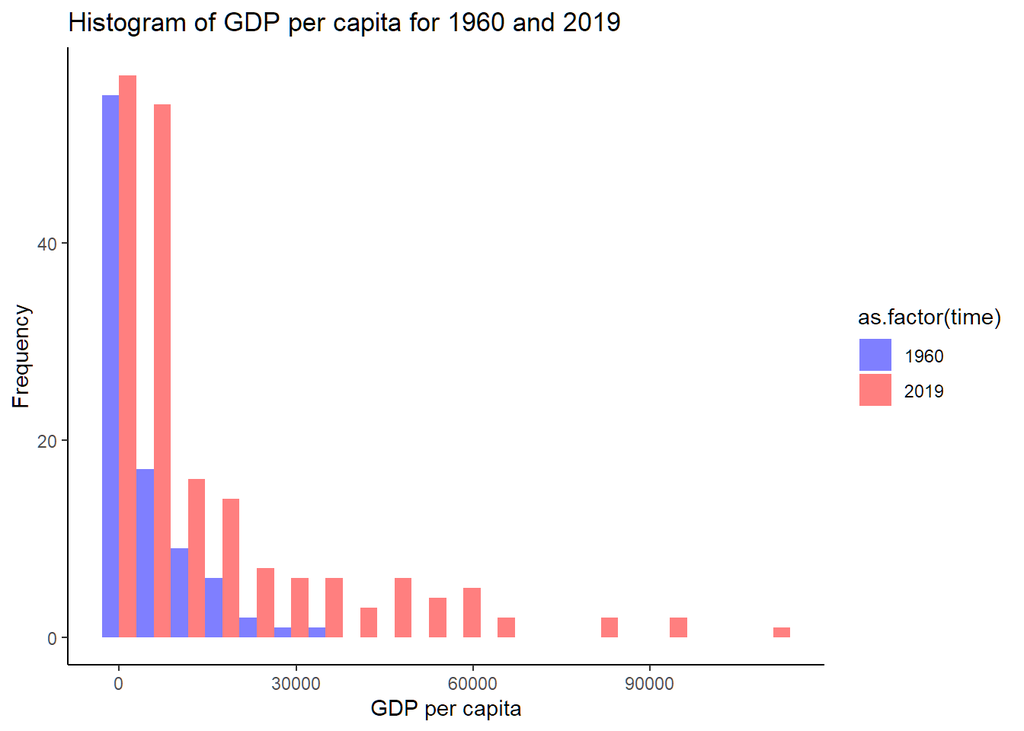

```r
gdp_1960_2019 <- gapdata %>%
  filter(time %in% c(1960, 2019) & !is.na(time) & !is.na(GDP_PC)) %>%
  select(time, GDP_PC)
ggplot(gdp_1960_2019, aes(x=GDP_PC, fill=as.factor(time))) +
  geom_histogram(alpha=0.5, position="dodge", bins=20) +
  scale_fill_manual(values=c("blue", "red")) +
  labs(title="Histogram of GDP per capita for 1960 and 2019",
       x="GDP per capita", y="Frequency") +
  theme_classic()
```

7. (6pt) What was the ranking of US in terms of life expectancy in 1960 and in 2019? (When counting from top.)  
   Hint: check out the function rank()!  
   Hint2: 17 for 1960.

```r
# Rank of the US in 1960
rank_1960 <- gapdata %>%
  filter(time == 1960 & !is.na(name)) %>%
  select(name, lifeExpectancy) %>%
  arrange(desc(lifeExpectancy)) %>%
  mutate(rank = rank(desc(lifeExpectancy))) %>%
  filter(name == "United States of America") %>%
  pull(rank)

# Rank of the US in 2019
rank_2019 <- gapdata %>%
  filter(time == 2019 & !is.na(name)) %>%
  select(name, lifeExpectancy) %>%
  arrange(desc(lifeExpectancy)) %>%
  mutate(rank = rank(desc(lifeExpectancy))) %>%
  filter(name == "United States of America") %>%
  pull(rank)

cat("\n   Rank of the US in terms of life expectancy in 1960: ", rank_1960, "\n")
```

Rank of the US in terms of life expectancy in 1960: 17

```r
cat("\n   Rank of the US in terms of life expectancy in 2019: ", rank_2019, "\n")
```

Rank of the US in terms of life expectancy in 2019: 46

```r
df_rank <- gapdata %>%
  filter(!is.na(lifeExpectancy) & !is.na(name) & !is.na(time)) %>%
  group_by(time) %>%
  mutate(rank = rank(lifeExpectancy, na.last = "keep")) %>%
  ungroup() %>%
  group_by(time) %>%
  mutate(rel_rank = rank / sum(!is.na(rank))) %>%
  ungroup()

# Show the relative rank for the US
knitr::kable(df_rank %>%
  filter(name == "United States of America") %>%
  select(time, rel_rank),align="c")
```

| time | rel_rank |
| --- | --- |
| 1960 | 0.9148936 |
| 1961 | 0.9312169 |
| 1962 | 0.9153439 |
| 1963 | 0.8989362 |
| 1964 | 0.8882979 |
| 1965 | 0.8941799 |
| 1966 | 0.8677249 |
| 1967 | 0.8941799 |
| 1968 | 0.8359788 |
| 1969 | 0.8730159 |
| 1970 | 0.8789474 |
| 1971 | 0.8888889 |
| 1972 | 0.8888889 |
| 1973 | 0.8789474 |
| 1974 | 0.8994709 |
| 1975 | 0.9153439 |
| 1976 | 0.9206349 |
| 1977 | 0.9206349 |
| 1978 | 0.9162304 |
| 1979 | 0.9315789 |
| 1980 | 0.8958333 |
| 1981 | 0.9109948 |
| 1982 | 0.9226804 |
| 1983 | 0.9218750 |
| 1984 | 0.9114583 |
| 1985 | 0.9062500 |
| 1986 | 0.8860104 |
| 1987 | 0.8826531 |
| 1988 | 0.8756477 |
| 1989 | 0.8808290 |
| 1990 | 0.8666667 |
| 1991 | 0.8622449 |
| 1992 | 0.8622449 |
| 1993 | 0.8505155 |
| 1994 | 0.8461538 |
| 1995 | 0.8418367 |
| 1996 | 0.8410256 |
| 1997 | 0.8585859 |
| 1998 | 0.8461538 |
| 1999 | 0.8418367 |
| 2000 | 0.8291457 |
| 2001 | 0.8172589 |
| 2002 | 0.8140704 |
| 2003 | 0.7969543 |
| 2004 | 0.8020305 |
| 2005 | 0.7979798 |
| 2006 | 0.7918782 |
| 2007 | 0.7979798 |
| 2008 | 0.8030303 |
| 2009 | 0.8181818 |
| 2010 | 0.8131313 |
| 2011 | 0.8121827 |
| 2012 | 0.8040201 |
| 2013 | 0.8071066 |
| 2014 | 0.7979798 |
| 2015 | 0.7878788 |
| 2016 | 0.7777778 |
| 2017 | 0.7766497 |
| 2018 | 0.7755102 |
| 2019 | 0.7704082 |

Finally tell us how many hours did you spend on this PS.  
I spent 15 hours on this assignment.